# Trends in ambulatory blood pressure monitoring use for confirmation or monitoring of hypertension and resistant hypertension among the commercially insured in the U.S., 2008–2017 - ScienceDirect

- [View **PDF**](https://www.sciencedirect.com/science/article/pii/S2590086220300100/pdfft?md5=92cfd055272ca72467fe03e91f74f1cb&pid=1-s2.0-S2590086220300100-main.pdf)

## Cited By (6)

## Figures (2)

[figure not shown]

## Tables (1)

1. Table 1

## Extras (1)

1. Multimedia component 1

## [International Journal of Cardiology Hypertension](https://www.sciencedirect.com/journal/international-journal-of-cardiology-hypertension)

[Volume 6](https://www.sciencedirect.com/journal/international-journal-of-cardiology-hypertension/vol/6/suppl/C), September 2020, 100033

# Research Paper Trends in ambulatory blood pressure monitoring use for confirmation or monitoring of hypertension and resistant hypertension among the commercially insured in the U.S., 2008–2017

https://doi.org/10.1016/j.ijchy.2020.100033[Get rights and content](https://s100.copyright.com/AppDispatchServlet?publisherName=ELS&contentID=S2590086220300100&orderBeanReset=true)

Under a Creative Commons [license](https://creativecommons.org/licenses/by-nc-nd/4.0/)

Open access

## Abstract

### Background

[Ambulatory blood pressure monitoring](https://www.sciencedirect.com/topics/medicine-and-dentistry/blood-pressure-monitoring) (ABPM) has been increasingly recommended for diagnosis confirmation and monitoring in patients with new-onset hypertension and apparent treatment-resistant hypertension (aTRH). We assessed insurance claims submitted for ABPM among a nationally representative sample of commercially insured U.S. patients.

### Methods

We conducted a retrospective cross-sectional analysis using the IBM MarketScan® commercial claims database from January 2008–December 2017, including 2 populations: those with incident treated hypertension (ITH; first [antihypertensive](https://www.sciencedirect.com/topics/medicine-and-dentistry/antihypertensive-agent) filled) or aTRH (first overlapping use of 4 antihypertensive agents). We identified ABPM claims filed within 6 months before to 6 months after the qualifying antihypertensive fill and determined prevalence of ABPM use overall and by year in each population.

### Results

In total, 2,820,303 patients met ITH criteria and 298,049 met aTRH criteria. Of those with ITH, 7650 (2.7 per 1000 persons) had ≥1 ABPM claim submitted, and annual ABPM prevalence ranged from 2.0 to 3.7 per 1000 persons, increasing over time (*P*<sub>trend</sub><0.0001). Among those with aTRH, 630 (2.1 per 1000 persons) had ≥1 ABPM claim submitted, and annual ABPM prevalence ranged from 1.6 to 2.7 per 1000 persons, decreasing over time (*P*<sub>trend</sub> = 0.054). Timing of ABPM claims suggested they were used primarily for diagnosis confirmation in ITH, and more evenly distributed between diagnosis confirmation and monitoring in aTRH.

### Conclusions

Despite guideline recommendations for more widescale use, ABPM appears to be used rarely in the U.S., with fewer than 0.5% of commercially insured patients with newly treated hypertension or aTRH having ABPM claims submitted to their insurance.

## Keywords

Blood pressure

Monitoring

ABPM

Hypertension

Resistant hypertension

## 1. Introduction

Office blood pressure (BP) serves as the primary diagnostic and treatment response criteria for hypertension in the United States. However, office BP often differs from out-of-office BP (e.g., 24-h [ambulatory BP monitoring](https://www.sciencedirect.com/topics/medicine-and-dentistry/blood-pressure-monitoring) [ABPM]), and the latter measurement provides more stable and reproducible estimates of BP and has greater prognostic ability in estimating cardiovascular risk [1]. Accordingly, hypertension guidelines over the past quarter century have increasingly recommended out-of-office BP monitoring for confirmation of hypertension diagnosis, particularly when ‘white coat’ hypertension is suspected, and to assess [antihypertensive](https://www.sciencedirect.com/topics/medicine-and-dentistry/antihypertensive-agent) treatment response [[2], [3], [4], [5]]. Similar recommendations have been made in consensus statements regarding treatment-resistant hypertension (TRH), a phenotype defined as requiring use of ≥4 antihypertensives to achieve BP control [[2], [3], [4], [5], [6], [7]]. Nevertheless, real-world use of out-of-office BP monitoring in the U.S. is not well-studied. Therefore, we examined recent trends in submitted insurance claims for ABPM among commercially insured U.S. adults with incident treated hypertension (ITH) or apparent TRH (aTRH).

## 2. Methods

We conducted a retrospective cross-sectional analysis of the IBM MarketScan® commercial claims database from January 2008 to December 2017. Marketscan is a nationwide administrative claims data warehouse including records of patient enrollment, inpatient and outpatient medical claims, expenditures, and outpatient prescription drug claims for over 150 million beneficiaries covered under a variety of health benefit plans. The database is generally considered representative of individuals receiving employer-sponsored health insurance in the U.S. (approximately 55% of the population) [8]. This study was approved by the University of Florida Institutional Review Board.

### 2.1. Study population

Supplemental Fig. S1 summarizes the study design for the ITH and [aTRH](https://www.sciencedirect.com/topics/medicine-and-dentistry/resistant-hypertension) cohorts. In both cohorts, we included adults (aged ≥18 years) with ≥1 hypertension diagnosis (ICD-9-CM, 401.X; ICD-10-CM, I10) and ≥1 [antihypertensive](https://www.sciencedirect.com/topics/medicine-and-dentistry/antihypertensive-agent) medication fill. The date of first prescription fill of an antihypertensive drug was defined as the index date for the ITH cohort. For the aTRH cohort, we identified patients with any period of ≥60 days of overlapping use of ≥4 antihypertensive drugs; each antihypertensive was required to have been filled at least twice, and ≥2 of the drugs had to be from a major antihypertensive class (angiotensin-converting enzyme inhibitor [ACE-I], [angiotensin receptor blocker](https://www.sciencedirect.com/topics/medicine-and-dentistry/angiotensin-receptor-antagonist) [ARB], [diuretic](https://www.sciencedirect.com/topics/medicine-and-dentistry/diuretic-agent), β-blocker, or [calcium channel blocker](https://www.sciencedirect.com/topics/medicine-and-dentistry/calcium-channel-blocking-agent) [CCB]) [6]. The first occurrence of overlapping use of ≥4 antihypertensive drugs was defined as the index date for the aTRH cohort. For both cohorts, we excluded individuals without a hypertension diagnosis within 6 months pre-index date and those who did not have continuous enrollment in their insurance plan for 6 months before and 6 months after the index date. We further excluded individuals with any history of heart failure (ICD-9-CM: 428.X and ICD-10-CM: 150.9) from the aTRH cohort given the overlapping medication indications and the lack of [BP measurements](https://www.sciencedirect.com/topics/medicine-and-dentistry/blood-pressure-measurement) in the dataset.

### 2.2. Study outcome and covariates

We evaluated claims submitted in the 6-month pre-index period through 6-month post-index period (outcome assessment window) for both cohorts. The primary outcome was [ABPM](https://www.sciencedirect.com/topics/medicine-and-dentistry/blood-pressure-monitoring) claims, identified using [Current Procedural Terminology](https://www.sciencedirect.com/topics/medicine-and-dentistry/current-procedural-terminology) (CPT) codes for full ABPM procedure (CPT 93784) and individual components, including procedure recording (93786), scan analysis & report (93788), and physician review & report (93790). Patient demographics such as age, gender, region and clinical characteristics (e.g., comorbidities) were assessed in the 6-month pre-index period for both cohorts.

### 2.3. Statistical analysis

Descriptive statistics were used to characterize the overall populations. Annual prevalence was estimated using all individuals with a first ABPM claim between January 1 and December 31 (inclusive) of a given year divided by all patients eligible to be included in the cohort for the respective year and presented as prevalence per 1000 persons. The Cochran-Armitage trend test was used to assess ABPM prevalence trends over time. A generalized linear model (GLM) with a negative binomial distribution and logit-link function was also employed to assess the change in ABPM prevalence over time controlling for covariates including age, sex, geographic region, prior history of diabetes mellitus, [chronic kidney disease](https://www.sciencedirect.com/topics/medicine-and-dentistry/chronic-kidney-disease), [peripheral vascular disease](https://www.sciencedirect.com/topics/medicine-and-dentistry/peripheral-vascular-disease), myocardial infarction or other [ischemic heart disease](https://www.sciencedirect.com/topics/medicine-and-dentistry/ischemic-heart-disease), peripheral vascular disease, [ischemic stroke](https://www.sciencedirect.com/topics/medicine-and-dentistry/brain-ischemia), and [hemorrhagic stroke](https://www.sciencedirect.com/topics/medicine-and-dentistry/cerebral-hemorrhage). Coefficients for the negative binomial models were computed as incidence rate ratios (IRR). Additional exploratory analyses were performed varying the outcome assessment window (365 days pre-index date to 365 days post-index date). Probability values were considered significant at <0.05. Statistical analyses were performed using SAS 9.4 (SAS Institute Inc., Cary, NC).

## 3. Results

We identified 2,820,303 patients meeting ITH criteria and 298,049 patients meeting aTRH criteria. Baseline characteristics for both cohorts are summarized in Table 1. As expected, the aTRH cohort was, on average, older, had a higher proportion of men, and a greater prevalence of most comorbid disease states, compared to those with ITH.

Table 1. Baseline characteristics of the incident treated hypertension and apparent treatment-resistant hypertension cohorts.

| Characteristics | Incident Treated Hypertension (N = 2,820,303) | Apparent Treatment-Resistant Hypertension (N = 298,049) |
| --- | --- | --- |
| **Age, years** |  |  |
| 18–35 | 506,735 (18.0%) | 4,126 (1.4%) |
| 36–50 | 1,064,222 (37.7%) | 52,944 (17.8%) |
| 51–64 | 1,231,136 (43.6%) | 232,645 (78.0%) |
| ≥65 | 18,210 (0.7%) | 8,334 (2.8%) |
| **Sex** |  |  |
| Males | 1,298,369 (46.0%) | 179,323 (60.2%) |
| Females | 1,521,934 (54.0%) | 118,726 (39.8%) |
| **Region** |  |  |
| Northeast | 451,126 (16.0%) | 44,974 (15.1%) |
| North Central | 650,170 (23.1%) | 71,174 (23.9%) |
| South | 1,319,656 (46.8%) | 150,770 (50.6%) |
| West | 378,674 (13.4%) | 29,729 (10.0%) |
| Unknown | 20,677 (0.7%) | 1,402 (0.4%) |
| **Prior medical history** |  |  |
| Diabetes mellitus | 369,212 (13.1%) | 116,362 (39.0%) |
| Chronic kidney disease | 31,512 (1.1%) | 23,760 (8.0%) |
| MI or other ischemic heart disease | 157,035 (5.6%) | 38,814 (13.0%) |
| Peripheral vascular disease | 47,555 (1.7%) | 10,590 (3.6%) |
| Ischemic stroke | 68,796 (2.4%) | 12,877 (4.3%) |
| Hemorrhagic stroke | 7,027 (0.2%) | 1,109 (0.4%) |
| Smoking | 35,853 (1.27%) | 2,714 (0.91%) |
| Obesity | 37,349 (1.32%) | 6,141 (2.06%) |
| Alcohol abuse | 43,344 (1.54%) | 3,162 (1.06%) |

Data are presented as n (%). Comorbidities were evaluated in the 180-day pre-index period. MI, myocardial infarction.

Of those with ITH, 7,650 had ≥1 ABPM claim submitted between 6 months prior to and 6 months after initiating treatment, for an overall prevalence of 2.7 per 1000 persons. Annual ABPM prevalence ranged from 2.0 to 3.7 per 1000 persons (Fig. 1, Panel A) with a statistically significant trend (Cochran-Armitage test, p < 0.0001). Similar results were obtained in the GLM model (Supplemental Table S1).

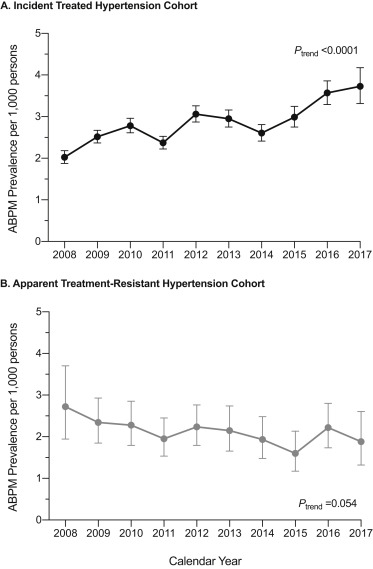

1. [Download : Download full-size image](https://ars.els-cdn.com/content/image/1-s2.0-S2590086220300100-gr1.jpg)

Fig. 1. **Annual prevalence of ambulatory blood pressure monitoring per 1000 beneficiaries in the incident treated hypertension (**Panel A**) and apparent treatment-resistant hypertension (**Panel B**) cohorts.** Error bars represent 95% confidence intervals. P-values displayed are from the Cochran-Armitage test.

Among those with aTRH, 630 patients had ≥1 ABPM claim submitted during the outcome assessment window around initiating a fourth agent, for an overall prevalence of 2.1 per 1000 persons. Annual ABPM prevalence ranged from 1.6 to 2.7 per 1000 persons (Fig. 1, Panel B). This trend was not statistically significant in either the Cochrane-Armitage test (p = 0.054) or GLM modeling (Supplemental Table S1).

In exploratory analyses, ABPM claims were primarily clustered within the 3 months prior to treatment initiation in the ITH cohort (Fig. 2, panel A), but considerably more evenly distributed around initiation of the fourth agent in the aTRH cohort (Fig. 2, panel B). These data suggest that ABPM was used most often for diagnosis confirmation in the ITH cohort, but approximately equally for confirmation and [treatment monitoring](https://www.sciencedirect.com/topics/medicine-and-dentistry/patient-monitoring) of aTRH.

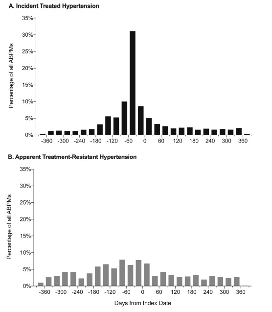

1. [Download : Download full-size image](https://ars.els-cdn.com/content/image/1-s2.0-S2590086220300100-gr2.jpg)

Fig. 2. **Frequency distribution of date of ambulatory blood pressure monitoring claims relative to the index date in the incident-treated hypertension (Panel A) and apparent treatment-resistant hypertension cohorts (Panel B).** Days from index date is calculated as ABPM claim date minus index date, where positive numbers indicate ABPM claim after the index date, and negative numbers indicate ABPM claim prior to the index date. For a patient with multiple ABPM claims on different dates (e.g., various components of ABPM billed on different dates), the date of the first claim is used.

## 4. Discussion

We examined the extent to which ABPM claims have been filed among commercially insured adults with hypertension in the U.S. in recent years. We focused on two populations, those with newly-treated hypertension and those meeting aTRH criteria, for whom current guidelines recommend out-of-office monitoring for confirmation of diagnosis or treatment response [2,9]. Our principal findings suggest the following: 1) ABPM is used quite infrequently overall (<0.5% of patients in either cohort), with relatively little difference in prevalence between those with newly-treated hypertension and those with aTRH in the overall study period; 2) ABPM use has increased modestly between 2008 and 2017 among those with newly-treated hypertension; and 3) ABPM use has remained stagnant, or possibly decreased modestly among those with aTRH requiring 4 antihypertensive drugs. To our knowledge, this study is among the first to examine trends in the real-world use of ABPM in patients with newly treated hypertension or aTRH.

Infrequent use of ABPM may be attributable to several factors. First, older hypertension guidelines, e.g., Joint National Committee (JNC) 6 (1997) and 7 guidelines (2003) recommended ABPM only in certain circumstances (e.g., suspected white coat hypertension, episodic or autonomic hypertension) [3,5]; thus, perhaps only a third or less of the ITH cohort may have warranted ABPM according to these criteria during our study time frame. Nevertheless, these same guidelines recommended ABPM for aTRH confirmation, as did the 2008 AHA scientific statement [9], and use of ABPM among those with aTRH was similarly infrequent. Secondly, reimbursement rates are often perceived as insufficient to justify the cost of performing ABPM routinely. Our prior research suggests that median reimbursement rates for ABPM range from approximately $86 to $96, depending on commercial plan type, although nearly 20% of submitted ABPM claims are not reimbursed at all [10]. Relatedly, patients often incur out-of-pocket expenses for ABPM, which may be cost-prohibitive. Thirdly, ABPM is cumbersome, both from the provider and patient perspective, and requires specialized training to implement. It seems unlikely that most primary care offices in the U.S., where the vast majority of hypertension care takes place, have the resources necessary to implement ABPM services. Finally, and perhaps most importantly, home BP monitoring (HBPM) is often recommended as a less-cumbersome alternative to ABPM. To date, HBPM has not been reimbursable except in very select circumstances. Thus, we could not adequately capture HBPM claims to assess the full extent of out-of-office monitoring in the U.S. in this study. However, data from the National Health and Nutrition Examination Survey (NHANES) suggest that up to 25% of patients with hypertension use HBPM at least sporadically [11].

The majority of ABPM claims in both cohorts were submitted for patients in the Southeastern U.S. The Marketscan database is known to modestly overrepresent beneficiaries from the South. However, this modest overrepresentation is insufficient to account for nearly half of all ABPM claims being filed from this region in the present study. The high proportion of ABPM use is likely more indicative of well-known inequities in prevalence and control of cardiovascular risk factors, including hypertension, in this “stroke belt” region [12]. Interestingly, our prior work found that claims from the Southeastern U.S. are less likely to be reimbursed than claims from the Northeast [10]. Taken together, these data suggest a greater need for ABPM in this region, as indicated by the number of claims filed, but lower likelihood of successful reimbursement in the most racially and socioeconomically diverse region in the U.S.

In sum, our data suggest that out-of-office monitoring with ABPM is used in only a small fraction of the population for which it is now recommended [13]. Subsequent research will need to explore the implementation of these out-of-office measurements following full implementation of the 2017 hypertension guidelines. Additionally, future research is needed to explore reimbursement of HBPM following implementation of recently approved [CPT](https://www.sciencedirect.com/topics/medicine-and-dentistry/current-procedural-terminology) codes for routine monitoring.

## Sources of funding

Dr. Smith is supported by the National Heart, Lung and Blood Institute (K01 HL138172).

## Credit author statement

**R. Desai:** Data curation and analysis, Visualization, Writing – original draft preparation; **H. Park:** Methodology, Writing – reviewing & editing; **E. Dietrich:** Conceptualization, Writing – reviewing & editing; **S.M. Smith:** Conceptualization; Methodology; Supervision, Visualization, Writing – reviewing & editing**.**

## Declaration of competing interest

None.

## Appendix A. Supplementary data

The following is the Supplementary data to this article:[Download : Download Acrobat PDF file (154KB)](https://ars.els-cdn.com/content/image/1-s2.0-S2590086220300100-mmc1.pdf)

Multimedia component 1.

## References

**[1]**

D. Shimbo, M. Abdalla, L. Falzon, *et al.*

**Role of ambulatory and home blood pressure monitoring in clinical practice: a narrative review**

Ann. Intern. Med., 163 (2015), pp. 691-700

[View Record in Scopus](https://www.scopus.com/inward/record.url?eid=2-s2.0-84946121412&partnerID=10&rel=R3.0.0)Google Scholar

**[2]**

B. Williams, G. Mancia, W. Spiering, *et al.*

**ESC/ESH Guidelines for the management of arterial hypertension**

Eur. Heart J., 2018 (39) (2018), pp. 3021-3104

[CrossRef](https://doi.org/10.1093/eurheartj/ehy339)[Google Scholar](https://scholar.google.com/scholar?q=ESCESH%20Guidelines%20for%20the%20management%20of%20arterial%20hypertension)

**[3]**

A.V. Chobanian, G.L. Bakris, H.R. Black, *et al.*

**Seventh report of the Joint national committee on prevention, detection, evaluation, and treatment of high blood pressure**

Hypertension, 42 (2003), pp. 1206-1252

[View Record in Scopus](https://www.scopus.com/inward/record.url?eid=2-s2.0-0347423198&partnerID=10&rel=R3.0.0)Google Scholar

**[4]**

P.K. Whelton, R.M. Carey, W.S. Aronow, *et al.*

**ACC/AHA/AAPA/ABC/ACPM/AGS/APhA/ASH/ASPC/NMA/PCNA guideline for the prevention, detection, evaluation, and management of high blood pressure in adults: a report of the American college of cardiology/American heart association task force on clinical practice guidelines**

Hypertension, 2018 (71) (2017), pp. e13-e115

Google Scholar

**[5]**

**The sixth report of the Joint National Committee on prevention, detection, evaluation, and treatment of high blood pressure**

Arch. Intern. Med., 157 (1997), pp. 2413-2446

[Google Scholar](https://scholar.google.com/scholar?q=The%20sixth%20report%20of%20the%20Joint%20National%20Committee%20on%20prevention,%20detection,%20evaluation,%20and%20treatment%20of%20high%20blood%20pressure)

**[6]**

A.Y. Hwang, C. Dave, S.M. Smith

**Trends in antihypertensive medication use among US patients with resistant hypertension, 2008 to 2014**

Hypertension, 68 (2016), pp. 1349-1354

[View Record in Scopus](https://www.scopus.com/inward/record.url?eid=2-s2.0-84992364762&partnerID=10&rel=R3.0.0)Google Scholar

**[7]**

R.M. Carey, P.K. Whelton Prevention

**Detection, evaluation, and management of high blood pressure in adults: synopsis of the 2017 American college of cardiology/American heart association hypertension guideline**

Ann. Intern. Med., 168 (2018), pp. 351-358

[View Record in Scopus](https://www.scopus.com/inward/record.url?eid=2-s2.0-85042470778&partnerID=10&rel=R3.0.0)Google Scholar

**[8]**

IBM Corporation, MarketScan Research Databases for Health Services Researchers (April 2019)

https://www.ibm.com/downloads/cas/6KNYVVQ2, Accessed 25th May 2020

[Google Scholar](https://scholar.google.com/scholar?q=IBM%20Corporation,%20MarketScan%20Research%20Databases%20for%20Health%20Services%20Researchers)

**[9]**

D.A. Calhoun, D. Jones, S. Textor, *et al.*

**Resistant hypertension: diagnosis, evaluation, and treatment. A scientific statement from the American heart association professional education committee of the council for high blood pressure research**

Hypertension, 51 (2008), pp. 1403-1419

[View Record in Scopus](https://www.scopus.com/inward/record.url?eid=2-s2.0-49249106417&partnerID=10&rel=R3.0.0)Google Scholar

**[10]**

E. Dietrich, R. Desai, M. Garg, H. Park, S.M. Smith

**Reimbursement of ambulatory blood pressure monitoring in the US commercial insurance marketplace**

J. Clin. Hypertens. (Greenwich), 22 (1) (2020), pp. 6-15

[CrossRef](https://doi.org/10.1111/jch.13772)[View Record in Scopus](https://www.scopus.com/inward/record.url?eid=2-s2.0-85076920098&partnerID=10&rel=R3.0.0)Google Scholar

**[11]**

Y. Ostchega, G. Zhang, B.K. Kit, T. Nwankwo

**Factors associated with home blood pressure monitoring among US adults: national health and nutrition examination Survey, 2011-2014**

Am. J. Hypertens., 30 (2017), pp. 1126-1132

[CrossRef](https://doi.org/10.1093/ajh/hpx101)Google Scholar

**[12]**

M.S. Loop, G. Howard, G. de Los Campos, *et al.*

**Heat maps of hypertension, diabetes mellitus, and smoking in the continental United States**

Circ Cardiovasc Qual Outcome, 10 (2017), Article e003350

[CrossRef](https://doi.org/10.1161/CIRCOUTCOMES.116.003350)[View Record in Scopus](https://www.scopus.com/inward/record.url?eid=2-s2.0-85009945416&partnerID=10&rel=R3.0.0)Google Scholar

**[13]**

J.N. Booth 3rd, D. Hubbard, S. Sakhuja, *et al.*

**Proportion of US adults recommended out-of-clinic blood pressure monitoring according to the 2017 hypertension clinical practice guidelines**

Hypertension, 74 (2019), pp. 399-406

[CrossRef](https://doi.org/10.1161/hypertensionaha.119.12775)[View Record in Scopus](https://www.scopus.com/inward/record.url?eid=2-s2.0-85069620305&partnerID=10&rel=R3.0.0)Google Scholar

## Cited by (6)

### Comparative Safety and Effectiveness of Aldosterone Antagonists Versus Beta-Blockers as Fourth Agents in Patients With Apparent Resistant Hypertension

- 2022, Hypertension

### Automated Office Blood Pressure and the Impact of Attendance and Rest on Diagnostic Accuracy

- 2022, American Journal of Hypertension

### Identifying and treating resistant hypertension in PRECISION: A randomized long-term clinical trial with aprocitentan

- 2022, Journal of Clinical Hypertension

### The Burden of Resistant Hypertension Across the World

- 2022, Current Hypertension Reports

### Advances in non‐invasive blood pressure monitoring

- 2021, Sensors

### Out-of-pocket payment for ambulatory blood pressure monitoring among commercially insured in the United States

- 2020, American Journal of Hypertension

© 2020 The Authors. Published by Elsevier B.V.

Citations

Captures

Social Media